# Detection and visualization of cell-cell interactions using `LRBaseDbi`, `LRBase.XXX.eg.db`, and `scTensor` package

Koki Tsuyuzaki, Manabu Ishii and Itoshi Nikaido

Laboratory for Bioinformatics Research, RIKEN Center for Biosystems Dynamics Reseach

k.t.the-answer@hotmail.co.jp

27 6月 2018

#### Package

scTensor 0.99.0

# 1 Introduction

## 1.1 About Cell-Cell Interaction (CCI)

Due to the rapid development of single-cell RNA-Seq (scRNA-Seq) technologies, wide variety of cell types have been found such as many organs of healty person, stem cell niche and cancer stem cell. Such complex systems are composed by communication between cells (cell-cell interaction or CCI). Some general framework for CCI detection in scRNA-Seq are proposed like below.

1. *in situ* hybridization (ISH) based method such as smFISH

   Jean-Charles Boisset, et. al., Mapping the physical network of cellular interactions, Nature methods, 2018
2. Doublet/Triplet based method such as ProximID$^{1}$
3. Ligand Receptor co-expression based method

   J. Gray Camp, et. al., Multilineage communication regulates human liver bud development from pluripotency, Nature, 2017

   Li Li, et. al., Single-Cell RNA-Seq Analysis Maps Development of Human Germline Cells and Gonadal Niche Interactions, Cell Stem Cell, 2017

   Joseph X. Zhou, Extracting Intercellular Signaling Network of Cancer Tissues using Ligand-Receptor Expression Patterns from Whole-tumor and Single-cell Transcriptomes, Scientific Reports, 2017

   Daniel A. Skelly, et. al., Single-Cell Transcriptional Profiling Reveals Cellular Diversity and Intercommunication in the Mouse Heart, Cell Reports, 2018

This document supports the third method, which seems the most general strategy without requirement of additional experiments except for scRNA-Seq.

Many studies are based on the Ligand-Receptor (LR)-pair list of FANTOM5 project as the evidence of CCI ( http://fantom.gsc.riken.jp/5/suppl/Ramilowski_et_al_2015/data/PairsLigRec.txt ). The project proposed the LR-candidate genes by following two reasons.

Jordan A. Ramilowski, A draft network of ligand-receptor-mediated multicellular signalling in human, Nature Communications, 2015

1. **Subcellular Localization**
   1. Known Annotation (UniProtKB and HPRD) : The term **“Secreted”** for candidate ligand genes and **“Plasma Membrane”** for candidate receptor genes
   2. Computational Prediction (LocTree3 and PolyPhobius)
2. **Physical Binding of Proteins** : Experimentally validated PPI (protein-protein interaction) information of HPRD and STRING

The project also merged the data with previous LR database such as IUPHAR/DLRP/HPMR and filter out the list without PMIDs.

Here, we extend the similar approarch to the construction of the LR-pair lists of 12 organsisms and implemented as multiple R/*Bioconductor* annotation packages for sustainable maintainance (*LRBaseDbi* and LRBase.XXX.eg.db-type packages, XXX is the abbreviation of scientific name of organisms such as Hsa: Homo sapiens). Besides, we also developed a tensor decomposition based algorithm for detection and visualization of CCI from scRNA-Seq (*scTensor*). This document provides the way to use *LRBaseDbi*, LRBase.XXX.eg.db-type packages, and *scTensor* package.

## 1.2 Dependencies of CCI-related Packages

Our CCI-related package is composed of some annotation packages and software packages.

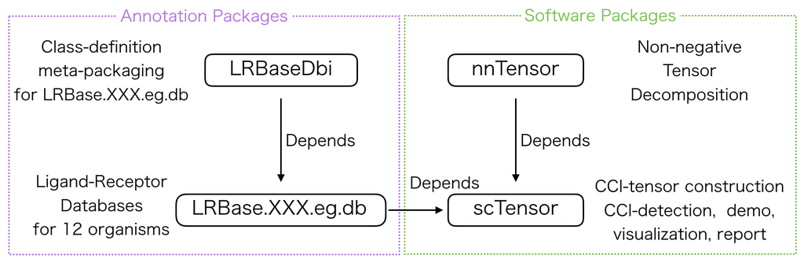

Dependencies of CCI-related Packages

*LRBaseDbi* package defines the class “LRBaseDb” for LRBase.XXX.eg.db-type packages such as *LRBase.Hsa.eg.db* and unify the object’s behavior such as column function. *nnTensor* which is a CRAN package, performs non-negative tensor decomposition, and *scTensor* internally imports the nnTensor. *scTensor* constructs CCI-tensor from a LRBase.XXX.eg.db package and scRNA-Seq dataset, decomposes to core tensor and factor matrices, and outputs HTML reports. See the next usage section for the details.

# 2 Usage

## 2.1 LRBase.XXX.eg.db (ligand-receptor database of 12 organisms)

To create the LR-list of 12 organisms, we used the information about the subcelluar localization of proteins from SWISSPROT (knowledge databaase) and TREMBL (computational prediction). We also used the PPI information from STRING database. The proteins which is assigned to the term **“Secreted”** and **“Cellular Membrane”** are retrived as candidate ligand and receptor, respectively. Finally, the LR-pairs which is registed in STRING are extracted as candidate LR-lists.

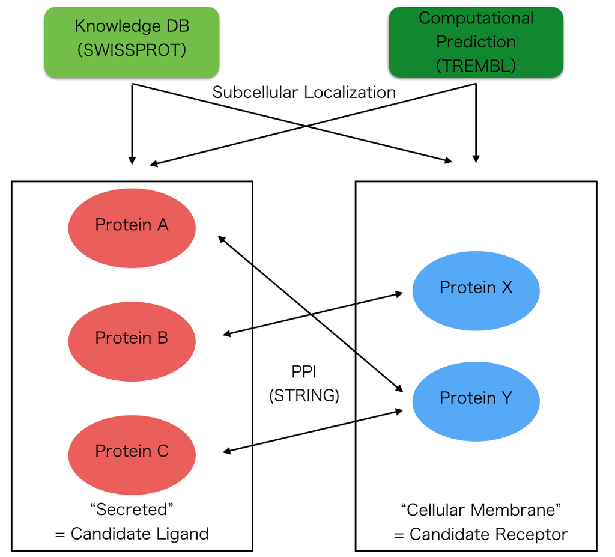

Pipeline for construction of LR-list of LRBase.XXX.eg.db

Following 12 organisms are implmented as LRBase.XXX.eg.db-type packages.

Table 1: The summary of 12 organisms of LRBase$_\cdot$XXX$_\cdot$eg$_\cdot$db packages

| Organisms | Package Name | # Swiss-Prot (Secreted / Membrane) | # TrEMBL (Secreted / Membrane) | # STRING (PPI) | # Pair (Swiss-Prot × STRING) | # Pair (TrEMBL × STRING) |  |
| --- | --- | --- | --- | --- | --- | --- | --- |
| $\textit{Homo sapiens}$ | LRBase.Hsa.eg.db | 1592 / 2269 | 176 / 334 | 18838 | 181023 | 5291 |  |
| $\textit{Mus musculus}$ | LRBase.Mmu.eg.db | 1309 / 1806 | 325 / 1555 | 19715 | 164259 | 6429 |  |
| $\textit{Arabidopsis thaliana}$ | LRBase.Ath.eg.db | 1260 / 1001 | 244 / 80 | 24174 | 72391 | 1045 |  |
| $\textit{Rattus norvegicus}$ | LRBase.Rno.eg.db | 643 / 983 | 232 / 1229 | 19963 | 44579 | 2191 |  |
| $\textit{Bos taurus}$ | LRBase.Bta.eg.db | 517 / 448 | 192 / 390 | 18349 | 17411 | 1445 |  |
| $\textit{Caenorhabditis elegans}$ | LRBase.Cel.eg.db | 198 / 247 | 28 / 60 | 13545 | 1121 | 21 |  |
| $\textit{Drosophila melanogaster}$ | LRBase.Dme.eg.db | 249 / 333 | 89 / 148 | 11903 | 6015 | 1001 |  |
| $\textit{Danio rerio}$ | LRBase.Dre.eg.db | 119 / 169 | 318 / 376 | 21746 | 1033 | 3649 |  |
| $\textit{Gallus gallus}$ | LRBase.Gga.eg.db | 175 / 173 | 185 / 154 | 13084 | 1639 | 697 |  |
| $\textit{Pongo abelii}$ | LRBase.Pab.eg.db | 80 / 134 | 212 / 211 | 16691 | 657 | 2199 |  |
| $\textit{Xenopus Silurana tropicalis}$ | LRBase.Xtr.eg.db | 57 / 83 | 141 / 114 | 15338 | 231 | 715 |  |
| $\textit{Sus scrofa}$ | LRBase.Ssc.eg.db | 223 / 153 | 202 / 445 | 18683 | 2657 | 1119 |  |

### 2.1.1 columns, keytypes, keys, and select

Some data access functions are available for LRBase.XXX.eg.db-type packages. The all data table are retrieved by 4 functions defined by *AnnotationDbi*; `columns`, `keytypes`, `keys`, and `select` and commonly implemented by *LRBaseDbi* package. `columns` returns the rows which we can retrieve in LRBase.XXX.eg.db-type packages. `keytypes` returns the rows which can be used as the optional parameter in `keys` and select functions against LRBase.XXX.eg.db-type packages. `keys` function returns the value of keytype. `select` function returns the rows in particular columns, which are having user-specified keys. This function returns the result as a dataframe. See the vignette of *AnnotationDbi* for more details.

```r
suppressPackageStartupMessages(library("LRBase.Hsa.eg.db"))

columns(LRBase.Hsa.eg.db)
```

```
## [1] "GENEID_L" "GENEID_R" "SOURCEDB" "SOURCEID"
```

```r
keytypes(LRBase.Hsa.eg.db)
```

```
## [1] "GENEID_L" "GENEID_R" "SOURCEDB" "SOURCEID"
```

```r
key_HSA <- keys(LRBase.Hsa.eg.db, keytype="GENEID_L")
head(select(LRBase.Hsa.eg.db, keys=key_HSA[1:2], columns=c("GENEID_L", "GENEID_R"), keytype="GENEID_L"))
```

```
##    GENEID_L GENEID_R
## 1      9068       14
## 3     23452       14
## 5     23452      207
## 7      9068     1436
## 9     23452     1436
## 11     9068     2041
```

### 2.1.2 Other functions

Other additional functions like `species`, `nomenclature`, and `listDatabases` are available. In each LRBase.XXX.eg.db-type package, `species` function returns the common name and `nomenclature` returns the scientific name. `listDatabases` function returns the source of data. `dbInfo` returns the information of the package. `dbfile` returns the directory where sqlite file is stored. `dbschema` returns the schema of database. `dbconn` returns the connection to the sqlite database.

```r
species(LRBase.Hsa.eg.db)
```

```
## [1] "Human"
```

```r
nomenclature(LRBase.Hsa.eg.db)
```

```
## [1] "Homo sapiens"
```

```r
listDatabases(LRBase.Hsa.eg.db)
```

```
##           SOURCEDB
## 1 SWISSPROT_STRING
## 2    TREMBL_STRING
```

```r
dbInfo(LRBase.Hsa.eg.db)
```

```
##               NAME                                              VALUE
## 1       SOURCEDATE                                        1-June-2018
## 2      SOURCENAME1                                          SWISSPROT
## 3      SOURCENAME2                                             TREMBL
## 4      SOURCENAME3                                             STRING
## 5       SOURCEURL1 http://www.uniprot.org/uniprot/?query=reviewed:yes
## 6       SOURCEURL2  http://www.uniprot.org/uniprot/?query=reviewed:no
## 7       SOURCEURL3              https://string-db.org/cgi/download.pl
## 8         DBSCHEMA                                   LRBase.Hsa.eg.db
## 9  DBSCHEMAVERSION                                                1.0
## 10        ORGANISM                                       Homo sapiens
## 11         SPECIES                                              Human
## 12         package                                      AnnotationDbi
## 13         Db type                                           LRBaseDb
## 14       LRVERSION                                               2018
```

```r
dbfile(LRBase.Hsa.eg.db)
```

```
## [1] "/Library/Frameworks/R.framework/Versions/3.5/Resources/library/LRBase.Hsa.eg.db/extdata/LRBase.Hsa.eg.db.sqlite"
```

```r
dbschema(LRBase.Hsa.eg.db)
```

```
## [1] "CREATE TABLE `METADATA` (\n  `NAME` TEXT,\n  `VALUE` TEXT\n)"
## [2] "CREATE TABLE `DATA` (\n  `GENEID_L` INTEGER,\n  `GENEID_R` INTEGER,\n  `SOURCEID` TEXT,\n  `SOURCEDB` TEXT\n)"
```

```r
dbconn(LRBase.Hsa.eg.db)
```

```
## <SQLiteConnection>
##   Path: /Library/Frameworks/R.framework/Versions/3.5/Resources/library/LRBase.Hsa.eg.db/extdata/LRBase.Hsa.eg.db.sqlite
##   Extensions: TRUE
```

Combined with `dbGetQuery` function of *RSQLite* package, more complicated queries also can be submitted.

```r
library("RSQLite")
dbGetQuery(dbconn(LRBase.Hsa.eg.db), "SELECT * FROM DATA WHERE GENEID_L = '9068' AND GENEID_R = '14' LIMIT 10")
```

```
##   GENEID_L GENEID_R
## 1     9068       14
## 2     9068       14
##                                                                                            SOURCEID
## 1 10025962|12975309|16303743|16710414|15489334|7743515|15489334|10329261|18634987|21269460|24275569
## 2 10025962|12975309|16303743|16710414|15489334|7743515|15489334|10329261|18634987|21269460|24275569
##           SOURCEDB
## 1 SWISSPROT_STRING
## 2 SWISSPROT_STRING
```

## 2.2 LRBaseDbi (Class definition and meta-packaging)

*LRBaseDbi* regulates the class definition of LRBaseDb object instantiated from `LRBaseDb`-class. Besides, *LRBaseDbi* package generates user’s original LRBase.XXX.eg.db-type packages by `makeLRBasePackage` function. This function is inspired by our previous package *MeSHDbi*, which constructs user’s original MeSH.XXX.eg.db-type packages. Here we call this function “meta”-packaging. The 12 LRBase.XXX.eg.db-type packages described above are also generated by this “meta”-packaging. In this case, only user have to specify are 1. a LR-list containing the columns “GENEID_L” (ligand NCBI Gene IDs) and “GENEID_R” (receptor NCBI Gene IDs) and 2. a meta information table describing the LR-list. `makeLRBasePackage` function generates LRBase.XXX.eg.db like below. The gene identifier is limited as NCBI Gene ID for now.

```r
suppressPackageStartupMessages(library("LRBaseDbi"))
example("makeLRBasePackage")
```

```
##
## mkLRBP> ## makeLRBasePackage enable users to construct
## mkLRBP> ## user's own custom LRBase package
## mkLRBP> data(FANTOM5)
##
## mkLRBP> head(FANTOM5)
##   GENEID_L GENEID_R SOURCEID SOURCEDB
## 1      805       19        -  FANTOM5
## 2      808       19        -  FANTOM5
## 3      801       19        -  FANTOM5
## 4     5360       19        -  FANTOM5
## 5     9699       19        -  FANTOM5
## 6    50944       19        -  FANTOM5
##
## mkLRBP> # We are also needed to prepare meta data as follows.
## mkLRBP> data(metaFANTOM5)
##
## mkLRBP> metaFANTOM5
##               NAME
## 1       SOURCEDATE
## 2       SOURCENAME
## 3        SOURCEURL
## 4         DBSCHEMA
## 5  DBSCHEMAVERSION
## 6         ORGANISM
## 7          SPECIES
## 8          package
## 9          Db type
## 10         VERSION
##                                                                            VALUE
## 1                                                                   22-July-2015
## 2                                                                        FANTOM5
## 3  http://fantom.gsc.riken.jp/5/suppl/Ramilowski_et_al_2015/data/PairsLigRec.txt
## 4                                                              FANTOM5.Hsa.eg.db
## 5                                                                            1.0
## 6                                                                   Homo sapiens
## 7                                                                          Human
## 8                                                                  AnnotationDbi
## 9                                                                       LRBaseDb
## 10                                                                          2018
##
## mkLRBP> ## sets up a temporary directory for this example
## mkLRBP> ## (users won't need to do this step)
## mkLRBP> destination <- tempfile()
##
## mkLRBP> dir.create(destination)
##
## mkLRBP> ## makes an Organism package for human called Homo.sapiens
## mkLRBP> makeLRBasePackage(pkgname = "FANTOM5.Hsa.eg.db",
## mkLRBP+     data = FANTOM5,
## mkLRBP+     metadata = metaFANTOM5,
## mkLRBP+     organism = "Homo sapiens",
## mkLRBP+     version = "0.99.0",
## mkLRBP+     maintainer = "Koki Tsuyuzaki <k.t.the-answer@hotmail.co.jp>",
## mkLRBP+     author = "Koki Tsuyuzaki",
## mkLRBP+     destDir = destination,
## mkLRBP+     license="Artistic-2.0")
## Creating package in /var/folders/k0/tk8gl4bj2_v2mbjx80ydsznw0000gn/T//RtmpnzbpvP/file31d1501751d/FANTOM5.Hsa.eg.db
```

Although any package name is acceptable, note that if the organism that the user summarized LR-list is also described above (Table 1), same XXX-character is recommended. This is because the HTML report function descibed later identifies the XXX-character and if the XXX is corresponding to the 12 organisms, the gene annotation of generated HTML report will become rich.

## 2.3 scTensor (CCI-tensor construction, decomposition, and HTML reporting)

Combined with LRBase.XXX.eg.db-type package and user’s gene expression matrix of scRNA-Seq, *scTensor* detects CCIs and generates HTML reports for exploratory data inspection. The algorithm of *scTensor* is as follows.

Firstly, *scTensor* sums up the cellular-level scRNA-Seq data as celltype-level matrix, searches the corresponding pair of genes in the rownames of the matrix, and extracted as vector.

Next, the all elements of extracted two vectors are summed up with all possible combination (*Kronecker* sum) and summarized as a matrix. Here, the multiple matrices can be represented as a three-order “tensor” (Ligand-Cell * Receptor-Cell * LR-Pair). *scTensor* decomposes the tensor into a small tensor (core tensor) and three factor matrices. Tensor decomposition is very similar to the matrix decomposition like PCA (principal component analysis). The core tensor is similar to eigenvalue of PCA; this means that how much the pattern is outstanding. Likewise, three matrices is similar to the PC scores/loadings of PCA; These represent which ligand-cell/receptor-cell/LR-pair are informative. When the matrices have negative values, interpreting which direction (+/-) is important and which is not, is difficult and laboring task. That’s why, *scTensor* performs non-negative Tucker decomposition (NTD), which is non-negative version of tensor decomposition (c.f. *nnTensor*).

Finaly, the result of NTD is summarized as HTML report. Because most of plots are visualized by *plotly* package, the presise information of the plot can be interactively confirmed by user’s on-site web browser. The three factor matrices can be interactively viewed and which celltypes and which LR-pairs are likely to be interacted each other. The mode-3 (LR-pair direction) sum of the core tensor is calculated and visualized as Ligand-Receptor Patterns. Detail of (Ligand-Cell, Receptor-Cell, LR-pair) Patterns are also visualized.

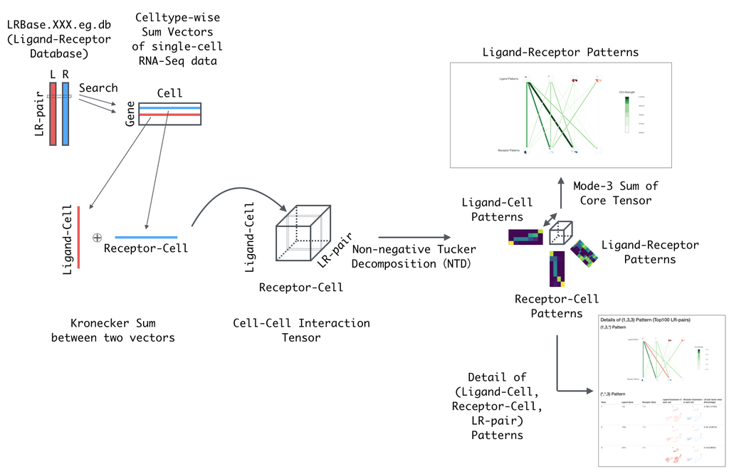

Algorithm of scTensor

### 2.3.1 Creating a `SingleCellExperiment` object

Here, we use the scRNA-Seq dataset of male gemline cells and somatic cells$^{3}$ GSE86146 as demo data. For saving the package size, the number of genes are strictlly reduced by the standard of highlly variable genes with threshold of p-value is 1E-150 (c.f. [Identifying highly variable genes](http://pklab.med.harvard.edu/scw2014/subpop_tutorial.html)). That’s why we won’t argue about the scientific discussion of the data here.

We assume that user have a scRNA-Seq data matrix containing expression count data summarised at the level of gene. First, we create a *SingleCellExperiment* object containing the data. The rows of the object correspond to features, and the columns correspond to cells. The gene identifier is limited as NCBI Gene ID for now.

To improve the interpretability of following HTML report, we highly recommend that user specifies the two-dimensional data of input data (e.g. PCA, t-SNE, or UMAP). Such information is easily specified by `reducedDims` function of *SingleCellExperiment* package and is saved to reducedDims slot of `SingleCellExperiment` object (1).

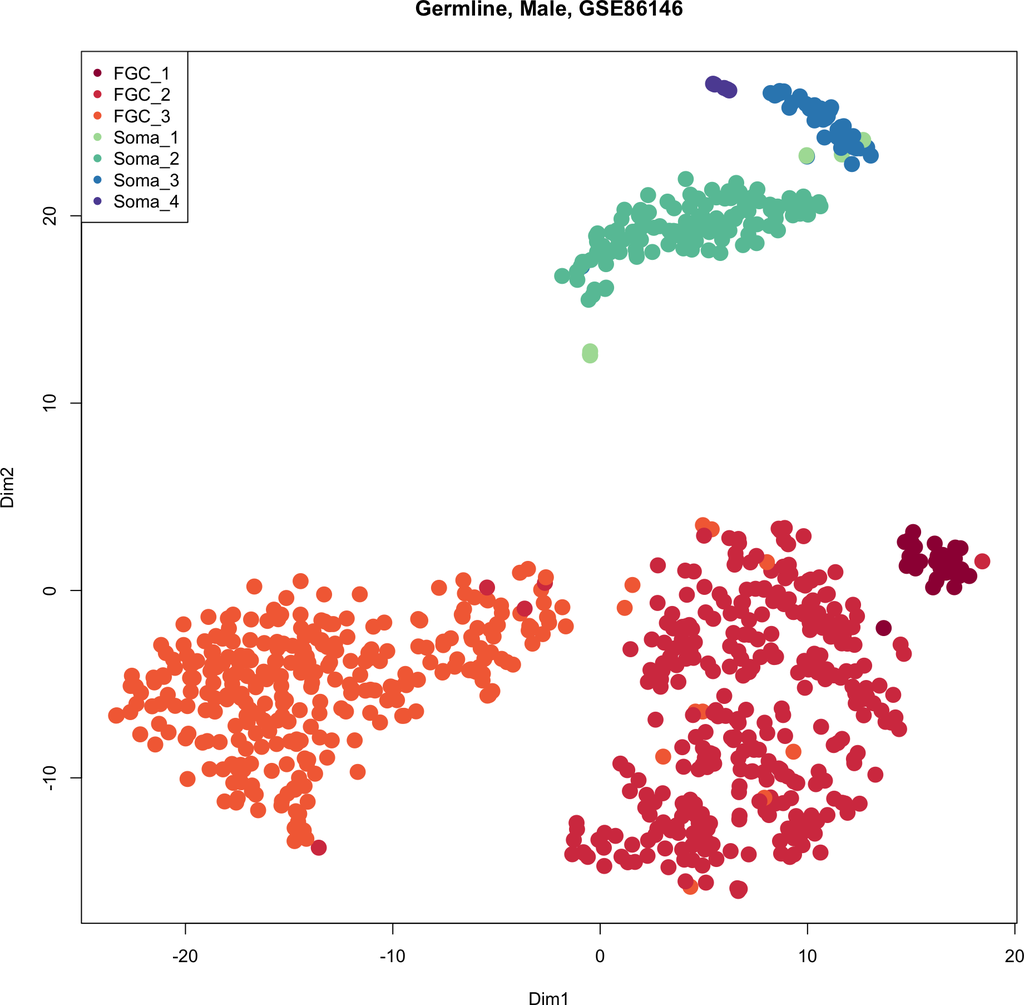

Figure 1: Germline, Male, GSE86146

```r
suppressPackageStartupMessages(library("scTensor"))
suppressPackageStartupMessages(library("SingleCellExperiment"))
suppressPackageStartupMessages(library("RColorBrewer"))

data(GermMale)
data(labelGermMale)
data(tsneGermMale)

sce <- SingleCellExperiment(assays=list(counts = GermMale))
reducedDims(sce) <- SimpleList(TSNE=tsneGermMale$Y)
plot(reducedDims(sce)[[1]], col=labelGermMale, pch=16, cex=2,
     xlab="Dim1", ylab="Dim2", main="Germline, Male, GSE86146")
legend("topleft", legend=c(paste0("FGC_", 1:3), paste0("Soma_", 1:4)), col=brewer.pal(11, "Spectral")[c(1:3, 8:11)], pch=16)
```

### 2.3.2 Parameter setting : cellCellSetting

To perform the tensor decomposition and HTML report, the user is supposed to specify 1. LRBase.XXX.eg.db, 2. cell type vector of each cell, 3. color vector of each cell, to `SingleCellExperiment` object. The corresponding information is registed to metadata slot of `SingleCellExperiment` object by `cellCellSetting` function.

```r
cellCellSetting(sce, LRBase.Hsa.eg.db, labelGermMale, names(labelGermMale))
```

### 2.3.3 CCI-tensor construction and decomposition : cellCellDecomp

After `cellCellSetting`, we can perform tensor decomposition by `cellCellDecomp`. Here the parameter `ranks` is specificed as dimension of core tensor. For example, c(3, 3, 2) means The data tensor is decomposed to 3 Ligand-pattern $\times$ 3 Receptor-pattern $\times$ 2 LR-pairs.

```r
cellCellDecomp(sce, ranks=c(3,3,2))
```

```
## Input data matrix may contains 96 gene symbols because the name contains some alphabets.
## scTensor uses only NCBI Gene IDs for now.
## Here, the gene symbols are removed and remaining 2451 NCBI Gene IDs are used for scTensor next step.
```

```
## 7 * 7 * 3081 Tensor is created
```

### 2.3.4 HTML Report : cellCellReport

If `cellCellDecomp` is properly finished, we can perform `cellCellReport` function to output the HTML report like belows.

```r
# print(tmp <- tempdir())
# cellCellReport(sce, reducedDimNames="TSNE", out.dir=tmp,
#     title="Cell-cell interaction within Germline, Male, GSE86146",
#     author="Koki Tsuyuzaki", thr=5)
# list.files(tmp)
```

After `cellCellReport`, multiple R markdown files, compiled HTML files, figures, R binary file containing the result of analysis are saved to `out.dir`. For more details, open the `index.html` by your web browser. Combined with cloud strage servise such as Amazon Simple Storage Service (S3), it can be simple web application and multiple person can confirm the same report simutaneously.